# Data overview

```r
library(dplyr)
```

Following your notation as best I can recall from what you shared the other day.

1. The 20m radius forest inventory plots ($B$’s) where the outcome timber volume is observed.

   ```r
   plot.y <- read.csv("outcome_y_plot.csv")
   plot.y %>% glimpse
   ```

   ```
   ## Rows: 62
   ## Columns: 6
   ## $ obs.plot.id  <int> 1, 2, 3, 4, 5, 6, 7, 8, 9, 10, 11, 12, 13, 14, 15, 16, 17…
   ## $ sub.region   <chr> "Frohn", "Frohn", "Frohn", "Frohn", "Frohn", "Frohn", "Fr…
   ## $ volume.m3.ha <dbl> 188.2855, 360.7815, 381.4172, 525.2733, 440.1881, 357.670…
   ## $ coords.x     <dbl> 404923.5, 405146.4, 405305.3, 405369.5, 405439.8, 405600.…
   ## $ coords.y     <dbl> 168395.4, 168559.4, 168631.5, 168651.3, 168688.9, 168804.…
   ## $ n.A          <int> 1260, 1262, 1258, 1260, 1254, 1257, 1257, 1266, 1257, 125…
   ```

   The columns are as follows:
   1. `obs.plot.id` is the unique plot number for each of the 62 plots.
   2. `sub.region` is the sub-region name as described in the paper. As we talked about, you might consider a site specific random effect for the regression slope parameters; however, a first pass model might just ignore sub-region.
   3. `volume.m3.ha` is the outcome variable $y$ that is the measurement of timber volume per ha on the plot.
   4. `n.a` is the number of 1-by-1 pixels ($A$’s) that have centroids that fall within the plot circle (this is the denominator in $h_{li}$). This should be real close to $\pi 20^2 = 1256.637$ (any differnece is due to pixel grid missalginment with the circles which causes pixel centroids to sometimes fall outside the plot circle’s boundary).
   5. `coords.x` easting coordinate in meters of the plot centroid.
   6. `coords.y` northing coordinate in meters of the plot centroid.
2. The 1-by-1 meter pixels of forest canopy height measurements over each 20m radius forest inventory plot ($A$’s). The average of these values over each plot is the predictor variable used in the paper.

   ```r
   plot.grid.x <- read.csv("predictor_x_grid.csv")
   plot.grid.x %>% glimpse
   ```

   ```
   ## Rows: 77,950
   ## Columns: 4
   ## $ obs.plot.id <int> 1, 1, 1, 1, 1, 1, 1, 1, 1, 1, 1, 1, 1, 1, 1, 1, 1, 1, 1, 1…
   ## $ height.m    <dbl> 11.057, 8.093, 2.650, 3.583, 8.598, 8.390, 5.198, 0.000, 1…
   ## $ coord.x     <int> 404920, 404921, 404922, 404923, 404924, 404925, 404926, 40…
   ## $ coord.y     <int> 168415, 168415, 168415, 168415, 168415, 168415, 168415, 16…
   ```

   The columns are as follows:
   1. `obs.plot.id` corresponds to the `obs.plot.id` in the `plot.y` file and should be used to link the $A$’s to $B$’s. See example below.
   2. `height.m` is the forest canopy height measurement on each 1-by-1 meter grid cell. This is used to generate the predictor, e.g., average height over each plot.
   3. `coords.x` easting coordiante in meters of the grid centroid.
   4. `coords.y` northing coordiante in meters of the grid centroid.

   For example, the non-spatial regression in the paper was as follows.

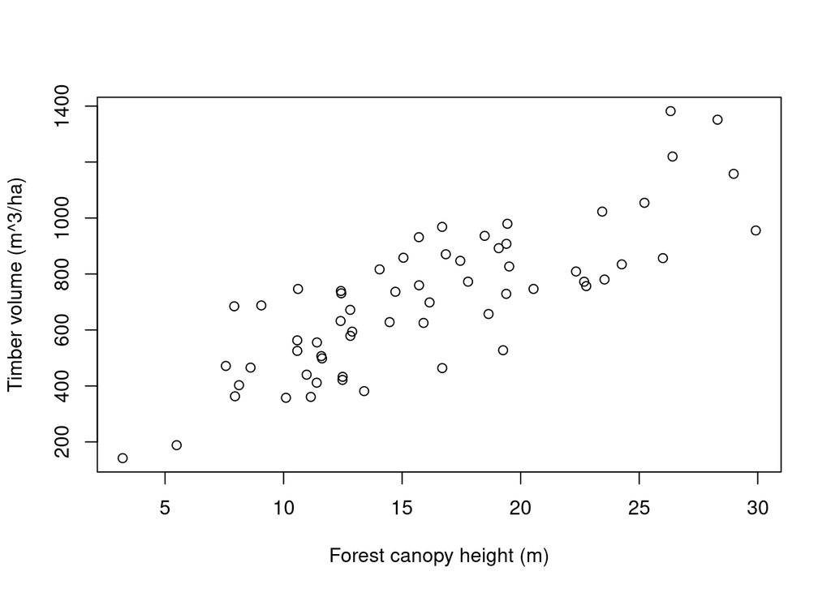

   ```r
   ## Compute the average height.m over each plot.
   x <- plot.grid.x %>% group_by(obs.plot.id) %>% summarize(height.mean = mean(height.m)) %>% select(height.mean) %>% pull
   y <- plot.y %>% select(volume.m3.ha) %>% pull
   plot(x, y, xlab = "Forest canopy height (m)", ylab = "Timber volume (m^3/ha)")
   ```

   ```r
   summary(lm(y ~ x))
   ```

   ```
   ##
   ## Call:
   ## lm(formula = y ~ x)
   ##
   ## Residuals:
   ##     Min      1Q  Median      3Q     Max
   ## -286.09 -134.85    4.21   92.94  330.20
   ##
   ## Coefficients:
   ##             Estimate Std. Error t value Pr(>|t|)
   ## (Intercept)  164.833     53.065   3.106  0.00289 **
   ## x             33.693      3.093  10.892 7.61e-16 ***
   ## ---
   ## Signif. codes:  0 '***' 0.001 '**' 0.01 '*' 0.05 '.' 0.1 ' ' 1
   ##
   ## Residual standard error: 149.4 on 60 degrees of freedom
   ## Multiple R-squared:  0.6641, Adjusted R-squared:  0.6585
   ## F-statistic: 118.6 on 1 and 60 DF,  p-value: 7.613e-16
   ```

   ```r
   pred.grid.x <- read.csv("prediction_x_grid.csv")
   pred.grid.x %>% glimpse
   ```

   ```
   ## Rows: 2,123,181
   ## Columns: 5
   ## $ pred.poly.id <int> 1, 1, 1, 1, 1, 1, 1, 1, 1, 1, 1, 1, 1, 1, 1, 1, 1, 1, 1, …
   ## $ sub.region   <chr> "Frohn", "Frohn", "Frohn", "Frohn", "Frohn", "Frohn", "Fr…
   ## $ height.m     <dbl> 21.410, 21.468, 20.660, 16.305, 1.505, 4.590, 5.765, 6.68…
   ## $ coords.x     <int> 405395, 405396, 405397, 405398, 405290, 405291, 405292, 4…
   ## $ coords.y     <int> 169435, 169435, 169435, 169435, 169434, 169434, 169434, 1…
   ```

   The columns are as follows:
   1. `pred.poly.id` a unique id for each of the 564 blowdown polygons.
   2. `sub.region` is the sub-region name as described in the paper.
   3. `height.m` is the forest canopy height measurement on each 1-by-1 meter grid cell. This is used to generate the predictor, e.g., average height over each plot.
   4. `coords.x` easting coordiante in meters of the grid centroid.
   5. `coords.y` northing coordiante in meters of the grid centroid.

   For example, a naive non-spatial regression similar to that in the paper is as follows.

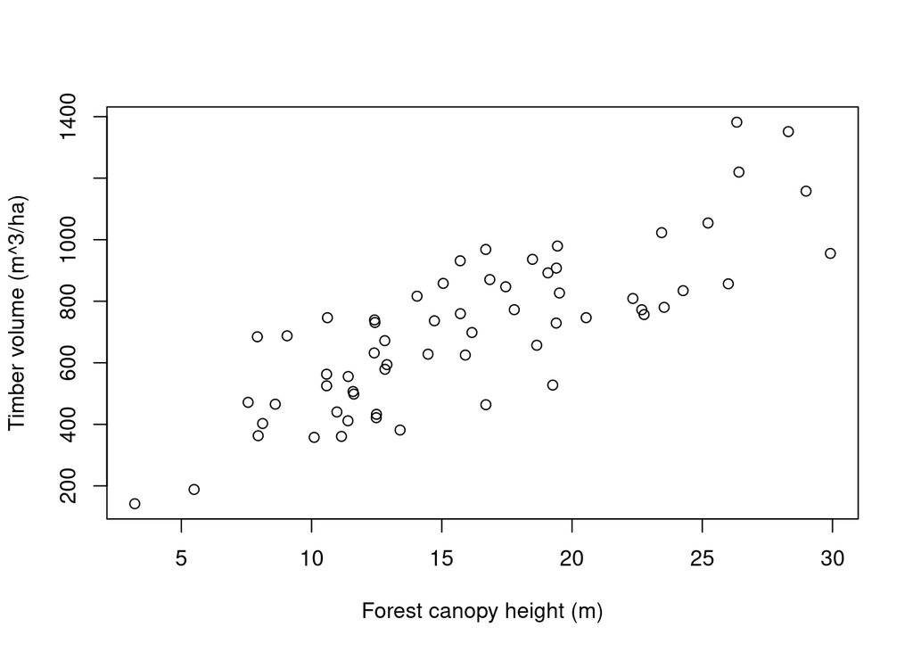

   ```r
   ## Compute the average height.m over each plot.
   x <- plot.grid.x %>% group_by(obs.plot.id) %>% summarize(height.mean = mean(height.m)) %>% select(height.mean) %>% pull
   y <- plot.y %>% select(volume.m3.ha) %>% pull
   plot(x, y, xlab = "Forest canopy height (m)", ylab = "Timber volume (m^3/ha)")
   ```

   ```r
   mod <- lm(y ~ x)

   ## Average forest canopy height over each blowdown.
   x.pred <- pred.grid.x %>% group_by(pred.poly.id) %>% summarize(height.mean = mean(height.m)) %>% select(height.mean) %>% pull

   ## Area of each blowdown in ha.
   area.ha.pred <- pred.grid.x %>% group_by(pred.poly.id) %>% summarize(area.ha.pred = n()/10000) %>% select(area.ha.pred) %>% pull

   ## Predicted *total* timber volume for blowdown.
   y.pred.m3.tot <- cbind(1, x.pred)%*%coefficients(mod)*area.ha.pred

   ## Check the estimated timber volume against Table 4 in the paper.
   check <- pred.grid.x %>% group_by(pred.poly.id) %>% summarize(sub.region = first(sub.region)) %>% cbind(., y.pred.m3.tot) %>% group_by(sub.region) %>% summarize(total.loss = sum(y.pred.m3.tot))
   check ## Looks pretty good!
   ```

   ```
   ## # A tibble: 5 x 2
   ##   sub.region total.loss
   ##   <chr>           <dbl>
   ## 1 Frohn          35044.
   ## 2 Laas           39335.
   ## 3 Liesing         2693.
   ## 4 Mauthen        30361.
   ## 5 Ploecken       33462.
   ```